# Cactus alignment

2024-04-29

### Note

Following includes codes used to generate an 79 way cactus alignment of birds. It uses bash and R codes interchangeably along with chunks that should be submitted as jobs using a resource manager in a supercomputing cluster (here we use slurm and snakemake). Please make sure you are running the codes in the correct interface.

# 1 Preprocessing

We selected 78 bird genomes and 1 genome for outgroup and aligned them using progressive cactus. The selection of taxa follows birds having short tarsi that were identified using bayou. See the file bayou.Rmd file for steps on running the bayou analysis. The 79 genomes and their relevant information is shown in the following table.

| Order | Family | Latin_name | Genome_Accession | Sex | Scaffold_Num | Scaffold_N50_bp | Scaffold_L50 | Total_Len_bp | File_ID | Notes |
| --- | --- | --- | --- | --- | --- | --- | --- | --- | --- | --- |
| Crocodylia | Gavialidae | Gavialis_gangeticus | GCA_001723915.1 | Female | 81 | 96076944 | 8 | 2640792433 | Gavialis_gangeticus_GCA001723915.fa.gz |  |
| Struthioniformes | Struthionidae | Struthio_camelus | ASM69896v1_HiC | Unknown | 5981 | 83444685 | 5 | 1225496327 | Struthio_camelus_ASM69896.fa.gz | https://www.dropbox.com/s/1g03spa7xo9aaq9/ASM69896v1_HiC.fasta.gz?dl=0 |
| Rheiformes | Rheidae | Rhea_americana | rheAme1 | Unknown | 1395 | 80688299 | 4 | 1161242837 | Rhea_americana_rheAme1.fa.gz | https://www.dropbox.com/s/c52npppt0m7e2dv/rheAme1_HiC.fasta.gz?dl=0 |
| Tinamiformes | Tinamidae | Eudromia_elegans | GCA013398775.1 | Female | 2603 | 6275819 | 50 | 958982151 | Eudromia_elegans_GCA013398775.fa.gz |  |
| Casuariiformes | Casuariidae | Dromaius_novaehollandiae | droNov1 | Unknown | 1863 | 82460724 | 5 | 1192718721 | Dromaius_novaehollandiae_droNov1.fa.gz | https://www.dropbox.com/s/bge457t6l9a5uqp/droNov1_HiC.fasta.gz?dl=0 |
| Anseriformes | Anatidae | Anas_platyrhynchos | GCA_000355885.1 | Female | 1665 | 77626585 | 5 | 1211992756 | Anas_platyrhynchos_GCA900411745.fa.gz |  |
| Galliformes | Phasianidae | Gallus_gallus4 | GCA_000002315.1 | Female | 16846 | 12877381 | 23 | 1046915324 | Gallus_gallus_GCA000002315.fa.gz |  |
| Galliformes | Phasianidae | Gallus_gallus7 | GCF_016699485.2 | Female | 214 | 90861225 | 4 | 1053332251 | Gallus_gallus_GCF016699485.fa.gz |  |
| Phoenicopteriformes | Phoenicopteridae | Phoenicopterus_ruber | GCA_009819775.1 | Female | 90 | 85472901 | 5 | 1246226932 | Phoenicopterus_ruber_GCA009819775.fa.gz |  |
| Columbiformes | Columbidae | Columba_livia | GCA_001887795.1 | Male | 91 | 24540102 | 11 | 1018016946 | Columba_livia_GCA001887795.fa.gz |  |
| Musophagiformes | Musophagidae | Tauraco_erythrolophus | GCA_009769465.1 | Female | 140 | 85562082 | 6 | 1252271553 | Tauraco_erythrolophus_GCA009769465.fa.gz |  |
| Cuculiformes | Cuculidae | Cuculus_canorus | GCA_017976375.1 | Female | 151 | 78325852 | 5 | 1180156273 | Cuculus_canorus_GCA017976375.fa.gz |  |
| Caprimulgiformes | Caprimulgidae | Caprimulgus_europaeus | GCA_907165065.1 | Female | 121 | 82614289 | 6 | 1177791212 | Caprimulgus_europaeus_GCA907165065.fa.gz |  |
| Apodiformes | Apodidae | Apus_apus | GCA_020740795.1 | Female | 109 | 115508478 | 4 | 1100361224 | Apus_apus_GCA020740795.fa.gz |  |
| Apodiformes | Trochilidae | Calypte_anna | GCA_003957555.2 | Female | 159 | 74081004 | 4 | 1059687259 | Calypte_anna_GCA003957555.fa.gz |  |
| Gruiformes | Rallidae | Porphyrio_hochstetteri | GCA_020800305.1 | Female | 174 | 71566193 | 5 | 1270294353 | Porphyrio_hochstetteri_GCA020800305.fa.gz |  |
| Charadriiformes | Charadriidae | Pluvialis_apricaria | GCA_017639485.1 | Female | 107 | 87527607 | 5 | 1247767512 | Pluvialis_apricaria_GCA017639485.fa.gz |  |
| Charadriiformes | Laridae | Sterna_hirundo | GCA_009819605.1 | Female | 123 | 85487239 | 5 | 1229972541 | Sterna_hirundo_GCA009819605.fa.gz |  |
| Sphenisciformes | Spheniscidae | Aptenodytes_patagonicus | GCA_010087175.1 | Unknown | 15968 | 2912628 | 122 | 1252291219 | Aptenodytes_patagonicus_GCA010087175.fa.gz |  |
| Sphenisciformes | Spheniscidae | Aptenodytes_forsteri | GCA_000699145.1 | Male | 29970 | 5071598 | 71 | 1257483768 | Aptenodytes_forsteri_GCA000699145.fa.gz |  |
| Sphenisciformes | Spheniscidae | Pygoscelis_adeliae | GCA_000699105.1 | Male | 90746 | 5047175 | 73 | 1226103150 | Pygoscelis_adeliae_GCA000699105.fa.gz |  |
| Sphenisciformes | Spheniscidae | Pygoscelis_papua | GCA_010090195.1 | Unknown | 18750 | 2789995 | 121 | 1306937499 | Pygoscelis_papua_GCA010090195.fa.gz |  |
| Sphenisciformes | Spheniscidae | Pygoscelis_antarcticus | GCA_010078415.1 | Unknown | 16691 | 6271244 | 57 | 1260447050 | Pygoscelis_antarcticus_GCA010078415.fa.gz |  |
| Sphenisciformes | Spheniscidae | Megadyptes_antipodes | GCA_010078485.1 | Unknown | 17379 | 23315117 | 17 | 1314943623 | Megadyptes_antipodes_GCA010078485.fa.gz |  |
| Sphenisciformes | Spheniscidae | Eudyptula_novaehollandiae | GCA_010078495.1 | Unknown | 15946 | 29280209 | 16 | 1353666924 | Eudyptula_novaehollandiae_GCA010078495.fa.gz |  |
| Sphenisciformes | Spheniscidae | Eudyptula_albosignata | GCA_010080465.1 | Unknown | 18591 | 21866543 | 17 | 1370511393 | Eudyptula_albosignata_GCA010080465.fa.gz |  |
| Sphenisciformes | Spheniscidae | Eudyptula_minor | GCA_010080355.1 | Unknown | 22396 | 21127646 | 19 | 1462615782 | Eudyptula_minor_GCA010080355.fa.gz |  |
| Sphenisciformes | Spheniscidae | Spheniscus_demersus | GCA_010077935.1 | Unknown | 15338 | 15386364 | 25 | 1275043525 | Spheniscus_demersus_GCA010077935.fa.gz |  |
| Sphenisciformes | Spheniscidae | Spheniscus_humboldti | GCA_010076325.1 | Unknown | 11265 | 6229819 | 66 | 1239252862 | Spheniscus_humboldti_GCA010076325.fa.gz |  |
| Sphenisciformes | Spheniscidae | Spheniscus_magellanicus | GCA_010076225.1 | Unknown | 13422 | 12679469 | 33 | 1260229131 | Spheniscus_magellanicus_GCA010076225.fa.gz |  |
| Sphenisciformes | Spheniscidae | Eudyptes_pachyrhynchus | GCA_010085335.1 | Unknown | 52188 | 8912950 | 39 | 1295505775 | Eudyptes_pachyrhynchus_GCA010085335.fa.gz |  |
| Sphenisciformes | Spheniscidae | Eudyptes_sclateri | GCA_010078445.1 | Unknown | 3484 | 1921244 | 174 | 1211402317 | Eudyptes_sclateri_GCA010078445.fa.gz |  |
| Sphenisciformes | Spheniscidae | Eudyptes_chrysolophus | GCA_010084205.1 | Unknown | 15753 | 13794837 | 29 | 1365695164 | Eudyptes_chrysolophus_GCA010084205.fa.gz |  |
| Sphenisciformes | Spheniscidae | Eudyptes_schlegeli | GCA_010080425.1 | Unknown | 17083 | 1894246 | 198 | 1308180354 | Eudyptes_schlegeli_GCA010080425.fa.gz |  |
| Sphenisciformes | Spheniscidae | Eudyptes_chrysocome | GCA_010085355.1 | Unknown | 3371 | 1949323 | 169 | 1231062710 | Eudyptes_chrysocome_GCA010085355.fa.gz |  |
| Sphenisciformes | Spheniscidae | Eudyptes_filholi | GCA_010085365.1 | Unknown | 2312 | 6429221 | 29 | 1223976468 | Eudyptes_filholi_GCA010085365.fa.gz |  |
| Sphenisciformes | Spheniscidae | Eudyptes_moseleyi | GCA_010082375.1 | Unknown | 20381 | 2252023 | 158 | 1301647863 | Eudyptes_moseleyi_GCA010082375.fa.gz |  |
| Procellariiformes | Procellariidae | Macronectes_giganteus | Mgig | Male | 861 | 27376298 | 14 | 1247958164 | Macronectes_giganteus_Mgig.fa.gz | http://kusglab.org/downloads/Mgig_genome_final.fasta.gz |
| Pelecaniformes | Threskiornithidae | Theristicus_caerulescens | GCA_020745775.1 | Female | 88 | 101368359 | 5 | 1203372763 | Theristicus_caerulescens_GCA020745775.fa.gz |  |
| Accipitriformes | Accipitridae | Aquila_chrysaetos | GCA_900496995.4 | Female | 144 | 46934974 | 9 | 1233704830 | Aquila_chrysaetos_GCA900496995.fa.gz |  |
| Strigiformes | Strigidae | Athene_cunicularia | GCA_003259725.1 | Male | 445 | 42147404 | 6 | 1157069330 | Athene_cunicularia_GCA003259725.fa.gz |  |
| Trogoniformes | Trogonidae | Trogon_surrucura | GCA_020746105.1 | Female | 182 | 82617956 | 5 | 1165749515 | Trogon_surrucura_GCA020746105.fa.gz |  |
| Bucerotiformes | Bucerotidae | Bucorvus_abyssinicus | GCA_009769605.1 | Female | 112 | 40274051 | 9 | 1132597561 | Bucorvus_abyssinicus_GCA009769605.fa.gz |  |
| Coraciiformes | Alcedinidae | Halcyon_senegalensis | GCA013397595.1 | Male | 3682 | 2092632 | 146 | 1137737933 | Halcyon_senegalensis_GCA013397595.fa.gz |  |
| Coraciiformes | Alcedinidae | Chloroceryle_aenea | GCA013399075.1 | Female | 67943 | 323453 | 918 | 1067751506 | Chloroceryle_aenea_GCA013399075.fa.gz |  |
| Coraciiformes | Alcedinidae | Actenoides_hombroni | GCA_024336885.1 | Unknown | 10367 | 10995457 | 14 | 1152258273 | Actenoides_hombroni_GCA024336885.fa.gz |  |
| Coraciiformes | Meropidae | Merops_nubicus | GCA_009819595.1 | Female | 109 | 49132790 | 9 | 1149356202 | Merops_nubicus_GCA009819595.fa.gz |  |
| Piciformes | Lybiidae | Pogoniulus_pusillus | GCA_015220805.1 | Female | 253 | 33994490 | 13 | 1272358903 | Pogoniulus_pusillus_GCA015220805.fa.gz |  |
| Piciformes | Picidae | Colaptes_auratus | GCA_015227895.2 | Unknown | 2369 | 43947546 | 11 | 1378187165 | Colaptes_auratus_GCA015227895.fa.gz |  |
| Falconiformes | Falconidae | Falco_peregrinus | GCA_024432695.1 | Female | 642 | 26062782 | 14 | 1153798512 | Falco_peregrinus_GCA024432695.fa.gz | Replacing GCA023634155 |
| Psittaciformes | Psittaculidae | Melopsittacus_undulatus | GCA_012275295.1 | Female | 864 | 104092594 | 5 | 1171617451 | Melopsittacus_undulatus_GCA012275295.fa.gz |  |
| Passeriformes | Acanthisittidae | Acanthisitta_chloris | GCA_016904835.1 | Female | 206 | 40827287 | 8 | 1077387582 | Acanthisitta_chloris_GCA016904835.fa.gz |  |
| Passeriformes | Tyrannidae | Myiozetetes_cayanensis | GCA_022539395.1 | Female | 1692 | 63679618 | 6 | 1075628138 | Myiozetetes_cayanensis_GCA022539395.fa.gz |  |
| Passeriformes | Pipridae | Chiroxiphia_lanceolata | GCA_009829145.1 | Female | 93 | 75608808 | 5 | 1089631598 | Chiroxiphia_lanceolata_GCA009829145.fa.gz |  |
| Passeriformes | Maluridae | Malurus_cyaneus | GCA_009741485.1 | Female | 4330 | 68113514 | 6 | 1078891882 | Malurus_cyaneus_GCA009741485.fa.gz |  |
| Passeriformes | Meliphagidae | Lichenostomus_cassidix | GCA_008360975.2 | Female | 894 | 63800663 | 6 | 1102944376 | Lichenostomus_cassidix_GCA008360975.fa.gz |  |
| Passeriformes | Laniidae | Lanius_collurio | GCA_020086605.1 | Male | 39581 | 23147665 | 16 | 1205288378 | Lanius_collurio_GCA020086605.fa.gz |  |
| Passeriformes | Corvidae | Corvus_cornix | GCA_000738735.5 | Male | 47 | 73732264 | 5 | 1030881721 | Corvus_cornix_GCA000738735.fa.gz |  |
| Passeriformes | Alaudidae | Eremophila_alpestris | GCA_009792885.1 | Male | 2714 | 9421811 | 30 | 1041035471 | Eremophila_alpestris_GCA009792885.fa.gz |  |
| Passeriformes | Paridae | Parus_major | GCA_001522545.2 | Male | 1675 | 71365269 | 5 | 1020310768 | Parus_major_GCA001522545.fa.gz |  |
| Passeriformes | Acrocephalidae | Acrocephalus_scirpaceus | GCA_910950805.1 | Unknown | 200 | 74438198 | 5 | 1075083815 | Acrocephalus_scirpaceus_GCA910950805.fa.gz |  |
| Passeriformes | Hirundinidae | Progne_subis | GCA_022316685.1 | Unknown | 2896 | 6129949 | 44 | 1165951862 | Progne_subis_GCA022316685.fa.gz |  |
| Passeriformes | Hirundinidae | Riparia_riparia | GCA_020917445.1 | Male | 19999 | 13690488 | 28 | 1093155110 | Riparia_riparia_GCA020917445.fa.gz |  |
| Passeriformes | Hirundinidae | Hirundo_rustica | GCA_015227805.3 | Female | 617 | 76187387 | 5 | 1105955550 | Hirundo_rustica_GCA015227805.fa.gz |  |
| Passeriformes | Pycnonotidae | Brachypodius_melanocephalos | GCA01339861.1 | Female | 3820 | 17537833 | 14 | 906727256 | Brachypodius_melanocephalos_GCA013398615.fa.gz | added_62993985_bp_of_potential_Z_but_no_resequencing_data_for_that_region |
| Passeriformes | Pycnonotidae | Pycnonotus_jocosus | GCA013400435.1 | Female | 142341 | 214665 | 1144 | 1035289814 | Pycnonotus_jocosus_GCA013400435.fa.gz |  |
| Passeriformes | Phylloscopidae | Phylloscopus_trochilus | GCA_016584745.1 | Male | 39596 | 12447930 | 24 | 1168570690 | Phylloscopus_trochilus_GCA016584745.fa.gz |  |
| Passeriformes | Sylviidae | Sylvia_atricapilla | GCA_009819655.1 | Unknown | 189 | 72978054 | 5 | 1066786587 | Sylvia_atricapilla_GCA009819655.fa.gz |  |
| Passeriformes | Certhiidae | Certhia_americana | GCA_018697195.1 | Unknown | 8309 | 64356598 | 6 | 1113356413 | Certhia_americana_GCA018697195.fa.gz |  |
| Passeriformes | Sturnidae | Sturnus_vulgaris | GCA_023376015.1 | Female | 1344 | 72244370 | 5 | 1043825371 | Sturnus_vulgaris_GCA023376015.fa.gz |  |
| Passeriformes | Muscicapidae | Ficedula_albicollis | GCA_000247815.2 | Male | 21428 | 64724594 | 6 | 1118343587 | Ficedula_albicollis_GCA000247815.fa.gz |  |
| Passeriformes | Estrildidae | Taeniopygia_guttata | GCA_003957565.4 | Male | 199 | 70982421 | 6 | 1056271262 | Taeniopygia_guttata_GCA003957565.fa.gz |  |
| Passeriformes | Passeridae | Passer_domesticus | GCA_001700915.1 | Female | 2301 | 68733010 | 6 | 1042720703 | Passer_domesticus_GCA001700915.fa.gz |  |
| Passeriformes | Motacillidae | Motacilla_alba | GCA_015832195.1 | Male | 619 | 72386170 | 6 | 1072670728 | Motacilla_alba_GCA015832195.fa.gz |  |
| Passeriformes | Fringillidae | Serinus_canaria | GCA_022539315.1 | Female | 684 | 72083177 | 5 | 1050336073 | Serinus_canaria_GCA022539315.fa.gz |  |
| Passeriformes | Emberizidae | Emberiza_elegans | GCA_022818055.1 | Male | 380 | 73992973 | 6 | 1222647951 | Emberiza_elegans_GCA022818055.fa.gz |  |
| Passeriformes | Icteridae | Molothrus_ater | GCA_012460135.1 | Female | 447 | 52124711 | 7 | 1087312585 | Molothrus_ater_GCA012460135.fa.gz |  |
| Passeriformes | Parulidae | Setophaga_coronata | GCA_001746935.2 | Male | 2109 | 71386623 | 5 | 1022651334 | Setophaga_coronata_GCA001746935.fa.gz |  |
| Passeriformes | Thraupidae | Diglossa_brunneiventris | GCA_019023105.1 | Female | 600 | 67281049 | 6 | 1079473785 | Diglossa_brunneiventris_GCA019023105.fa.gz |  |

## 1.1 Preparing genome data

Get the appropriate files from NCBI or other sources (provided in Notes column). Rename all files as listed in the File_ID column of the table.

Important: Gunzip all the files, the cactus pipeline does note work with gzipped or bgzipped files.

Clean the headers of the scaffold names. We got rid of any extra elements in the scaffold line except for the NCBI Accession Number. This can be easily accomplished by using the following command. Replace the genome.fa with the name of the genomes. You can loop over all the files to run the command on all the fasta files

```bash
#bash
for FILE in ./*.fa; do
  sed -i 's/\(>[A-Z]*[0-9]*\.[0-9]\).*/\1/' FILE
done
```

Use **samtools faidx** to generate index files for each genome. Small scaffolds may cause issues with aligning using cactus. So we remove all scaffolds less than 1000 bp.

```r
#R
#load all fai index files
index_files <- list.files("./", pattern = "*.fa.gz.fai", full.names = T)
for (file in index_files){
  file_open <- read.table(file, sep="\t", header = F)
  species <- gsub(".fa.gz.fai", "", basename(file), fixed = T)
  file_keep_scafs <- subset(file_open, V2 >= 1000)
  #samtools based format scaffold:start-end
  file_keep_scafs$V6 <- paste(file_keep_scafs$V1, ":1-", file_keep_scafs$V2, sep = "")
  write.table(file_keep_scafs$V6, paste(species,".txt", sep = ""),
              quote = F, row.names = F, col.names = F)
}
```

```bash
#bash
for FILE in ./*.txt; do
  species=$(basename $FILE .txt)
  genomes=$(basename $(find . -type f -name $species*.fa -print) .fa)
  echo $genomes
  samtools faidx ${genomes}.fa -r ${species}.txt > ${genomes}_1000.fa
  mv ${genomes}_1000.fa ${genomes}.fa
done
```

## 1.2 Note: Genome soft masking

The cactus snakemake pipeline will get stuck if genomes are not masked. Most genomes from NCBI are already masked but still some genomes might give you issues. The snakemake cactus pipeline does initially mask the genome but even that does not work sometimes. I would recommend running RepeatModeler and RepeatMasker on genomes that fail or stall. We had to do this for the *Macronectes giganteus* genome.

```bash
#bash
source activate repeatmodeler

BuildDatabase -name Mgig -engine ncbi Macronectes_giganteus_Mgig.fa
RepeatModeler -engine ncbi -pa 20 -database Mgig
RepeatMasker -species Aves -parallel 20 -xsmall -s Macronectes_giganteus_Mgig.fa
RepeatMasker -lib Mgig-families.fa -parallel 20 -xsmall -s Macronectes_giganteus_Mgig.fa.masked
```

## 1.3 Getting the tree

We subset the requisite tips and updated the names of the taxa to match the taxon names in our samples.

```r
library(ape)
library(phytools)
big_tree <- read.tree("b10k.tree")
index_table <- readxl::read_xlsx("genome_list.xlsx")

#Listed taxa have different names in tree versus our sample sheet
species_all <- c(intersect(big_tree$tip.label, index_table$Latin_name), "Lichenostomus_melanops",
                 "Corvus_corone", "Brachypodius_atriceps", "Emberiza_buchanani", "Gallus_gallus")

#Eudyptula minor has been split into four species for which we have genomes
#We created a polytomy at node with Eudpytula minor to include the four other species
all_tree <- keep.tip(big_tree, species_all)
all_tree <- bind.tip(all_tree, "Eudyptula_novaehollandiae", where = which(all_tree$tip.label=="Eudyptula_minor"))
all_tree <- bind.tip(all_tree, "Eudyptula_albosignata", where = which(all_tree$tip.label=="Eudyptula_minor"))
all_tree <- bind.tip(all_tree, "Eudyptes_schlegeli", where = which(all_tree$tip.label=="Eudyptes_chrysolophus"))

#Eudyptula chrysocome has been split into two species for which we have genomes
#We created a polytomy at node with Eudpytula chryscome to include the two other species
all_tree <- bind.tip(all_tree, "Eudyptes_filholi", where = which(all_tree$tip.label=="Eudyptes_chrysocome"))

#The following species have had their names changed or been split but we only need one taxa
#These nodes were renamed
all_tree$tip.label[which(all_tree$tip.label == "Lichenostomus_melanops")] <- "Lichenostomus_cassidix"
all_tree$tip.label[which(all_tree$tip.label == "Corvus_corone")] <- "Corvus_cornix"
all_tree$tip.label[which(all_tree$tip.label == "Brachypodius_atriceps")] <- "Brachypodius_melanocephalos"
all_tree$tip.label[which(all_tree$tip.label == "Emberiza_buchanani")] <- "Emberiza_elegans"

#Since we included two gallus gallus genomes in the cactus file, we need to duplicate
#and rename that node
all_tree$tip.label[which(all_tree$tip.label == "Gallus_gallus")] <- "Gallus_gallus4"
all_tree <- bind.tip(all_tree, "Gallus_gallus7", where = which(all_tree$tip.label=="Gallus_gallus4"))

#Add an outgroup node for the gharial genome
all_tree <- bind.tip(all_tree, "Gavialis_gangeticus", where = "root")

#plot(all_tree, root.edge = T)
write.tree(all_tree, file="all_tree.tree")
```

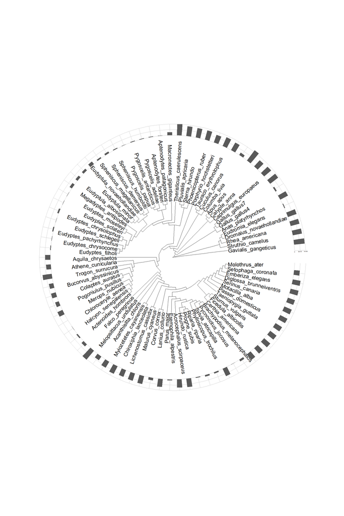

```r
library(ape)
library(ggplot2)
library(ggtree)
library(ggtreeExtra)
tree <- read.tree("all_tree.tree")
index_table <- readxl::read_xlsx("genome_list.xlsx")
#plot(tree)

p <- ggtree(tree, layout="circular", size=0.1)+
  geom_tiplab(size=4)+
  geom_fruit(data=index_table,
             geom=geom_bar,
             mapping = aes(y=Latin_name, x=Scaffold_N50_bp),
             stat="identity",
             width=0.5,
             pwidth = 0.3,
             orientation="y",
             offset=1.2,
             grid.params = list(vline = TRUE),
             axis.params = list(axis="x",
                               text.size=1))
p
```

## 1.4 Creating the cactus map file

This file has a simple format, the first line includes the newick tree. The subsequent lines include two columns, first column will include the name of the node (aka species name) and the second column will include the location of the file.

# 2 Running snakemake

Check this website for scripts and instruction to run this snakemake code:  
https://github.com/gwct/GenomeAnnotation/tree/master/genome_alignment

The following code was run on Harvard Supercomputing Cluster and ran for ~90 days.

```bash
#!/bin/bash
#SBATCH -c 1
#SBATCH -t 99-00:00
#SBATCH -p holy-smokes
#SBATCH --nodelist=holy7c0908
#SBATCH --mem=5000
#SBATCH -o ./logs/cac_%j.out
#SBATCH -e ./logs/cac_%j.err

cd /n/holyscratch01/informatics/sshakya/genomes_cactus/

source activate PhyloAcc

singularity exec --cleanenv ~/cactus_v2.1.1-gpu.sif cactus-prepare /n/holyscratch01/informatics/sshakya/genomes_cactus/cactus_snakemake/new_bird_aln.txt --outDir /n/holyscratch01/informatics/sshakya/genomes_cactus/cactus_snakemake/snakemake_out --jobStore /n/holyscratch01/informatics/sshakya/genomes_cactus/cactus_snakemake/snakemake_temp --gpu

snakemake -p -s ~/GenomeAnnotation/genome_alignment/cactus-gpu-snakemake/cactus_gpu.smk --configfile /n/holyscratch01/informatics/sshakya/genomes_cactus/all_birds_config.yaml --profile ~/GenomeAnnotation/genome_alignment/cactus-gpu-snakemake/profiles/slurm_profile/
```